# Take-home Exercise 6

### Analytics

Before proceeding with the network analysis, first let us examine the data. Here the weights calculated are single numbers. A point estimate is a single number, such as a mean. Uncertainty is expressed as standard error, confidence interval, or credible interval.

```r
data_edges$Weekday <- factor(data_edges$Weekday, level = c('Sunday','Monday','Tuesday','Wednesday','Thursday','Friday','Saturday'))
my_sum <-  data_edges %>%
  group_by(Weekday) %>%
  dplyr::summarise(
    n=n(),
    mean=mean(Weight),
    sd=sd(Weight)
    ) %>%
  mutate(se=sd/sqrt(n-1))

knitr::kable(head(my_sum), format = 'html')
```

| Weekday | n | mean | sd | se |
| --- | --- | --- | --- | --- |
| Sunday | 23504 | 2.729238 | 0.7992271 | 0.0052132 |
| Monday | 26640 | 2.718243 | 0.7881383 | 0.0048288 |
| Tuesday | 26428 | 2.670425 | 0.7917778 | 0.0048706 |
| Wednesday | 25204 | 2.625218 | 0.7940233 | 0.0050016 |
| Thursday | 23954 | 2.588211 | 0.7889700 | 0.0050978 |
| Friday | 28372 | 2.747286 | 1.0521967 | 0.0062468 |

The code chunk below is used to reveal the standard error of mean weights score by weekdays

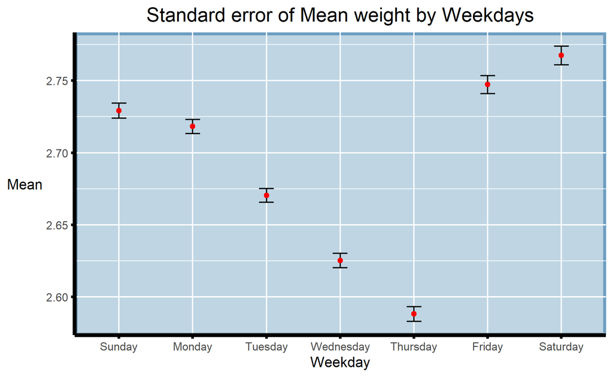

```r
ggplot(my_sum) +
  geom_errorbar(
    aes(x=Weekday,
        ymin=mean-se,
        ymax=mean+se,
        y=mean),
    width=0.2,
    colour="black",
    alpha=0.9,
    size=0.5) +
  geom_point(aes
           (x=Weekday,
            y=mean),
           stat="identity",
           color="red",
           size = 1.5,
           alpha=1) +
  xlab('Weekday')+
  ylab('Mean')+
  labs(title="Standard error of Mean weight by Weekdays")+
  theme(panel.background = element_rect(fill = "#BFD5E3", colour = "#6D9EC1",
                                size = 2, linetype = "solid"),
  panel.grid.major = element_line(size = 0.5, linetype = 'solid',
                                colour = "white"),
  panel.grid.minor = element_line(size = 0.25, linetype = 'solid',
                                colour = "white"),
  axis.line = element_line(size = 1.5, colour = "black"),
  axis.ticks = element_line(colour = "black", size = rel(2)),
  plot.title = element_text(size=15, hjust = 0.5),
  axis.title.y.left = element_text(vjust = 0.5),
  axis.title.y=element_text(angle=0))
```

### Observation

In the code chunk below, stat_gradientinterval() of ggdist is used to build a visual for displaying distribution of weights by weekdays.

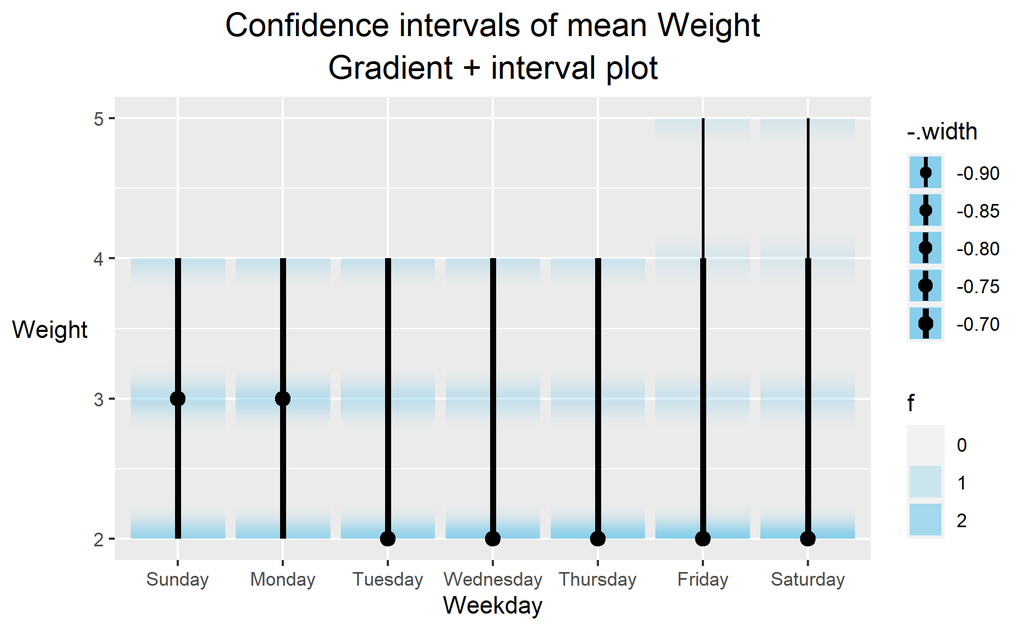

```r
data_edges %>%
  ggplot(aes(x=Weekday,
             y = Weight)) +
  stat_gradientinterval(
    fill = "skyblue",
    show.legend = TRUE
  ) +
  labs(
    title = "Confidence intervals of mean Weight",
    subtitle = "Gradient + interval plot")+
  theme(plot.title = element_text(size=15, hjust = 0.5),
        plot.subtitle = element_text(size=15, hjust = 0.5),
        axis.title.y.left = element_text(vjust = 0.5),
        axis.title.y=element_text(angle=0))
```

### Observation

The above graph shows various confidence levels from 70 - 90 with varying colour intensity.

### Reviewing the data

```r
glimpse(data_edges)
```

```
Rows: 181,836
Columns: 4
$ participantIdFrom <dbl> 1, 1, 1, 1, 1, 1, 1, 1, 1, 1, 1, 1, 1, 1, ~
$ participantIdTo   <dbl> 282, 282, 282, 282, 282, 282, 282, 300, 30~
$ Weekday           <fct> Friday, Monday, Saturday, Sunday, Thursday~
$ Weight            <int> 3, 2, 3, 2, 2, 2, 2, 2, 2, 2, 2, 2, 2, 2, ~
```

```r
jov0.9 <- data_nodes %>%
  filter(joviality > 0.95)

jovEdge <- data_edges %>%
  filter(participantIdFrom %in% jov0.9$participantId & participantIdTo %in% jov0.9$participantId)

jovNode <-jov0.9 %>%
  filter(participantId %in% jovEdge$participantIdFrom & participantId %in% jovEdge$participantIdTo)
```

### Building data model

The below code chunk is to build an tidygraph’s network graph data.frame using `tbl_graph()` of tinygraph package.

```r
social_graph <- graph_from_data_frame(jovEdge, vertices = jovNode) %>%
  as_tbl_graph() %>%
  activate(edges) %>%
  arrange(desc(Weight))
social_graph
```

```
# A tbl_graph: 46 nodes and 1506 edges
#
# A directed multigraph with 1 component
#
# Edge Data: 1,506 x 4 (active)
   from    to Weekday  Weight
  <int> <int> <chr>     <int>
1     4     5 Friday        5
2     4     5 Saturday      5
3     5     4 Friday        5
4     5     4 Saturday      5
5     6    13 Friday        5
6     8    11 Friday        5
# ... with 1,500 more rows
#
# Node Data: 46 x 8
  name  householdSize haveKids   age educationLevel interestGroup
  <chr>         <dbl> <lgl>    <dbl> <chr>          <chr>
1 7                 3 TRUE        27 Bachelors      A
2 82                2 FALSE       40 Graduate       H
3 104               2 FALSE       47 HighSchoolOrC~ F
# ... with 43 more rows, and 2 more variables: joviality <dbl>,
#   ageGroup <chr>
```

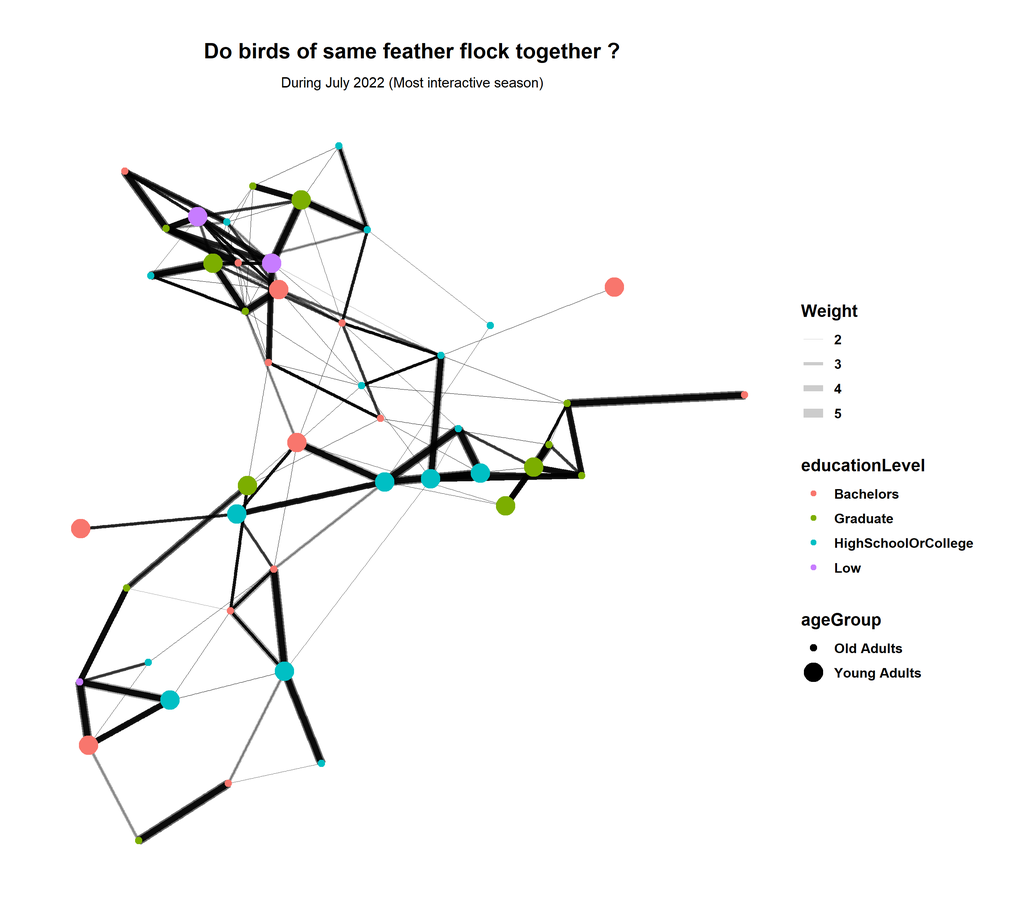

```r
g <- ggraph(social_graph,
            layout = "nicely") +
  geom_edge_link(aes(width=Weight),
                 alpha=0.2) +
  scale_edge_width(range = c(0.1, 3)) +
  geom_node_point(aes(colour = educationLevel,
                      size = ageGroup))
 g + theme_graph() +
  labs(fill = "Education Level",title="Do birds of same feather flock together ?",
       subtitle = "During July 2022 (Most interactive season)") +
  theme(plot.title = element_text(size=15, hjust = 0.5),
        plot.subtitle  = element_text(size = 10, hjust = 0.5),
        text = element_text(size=12,face="bold"))
```

### Observations:

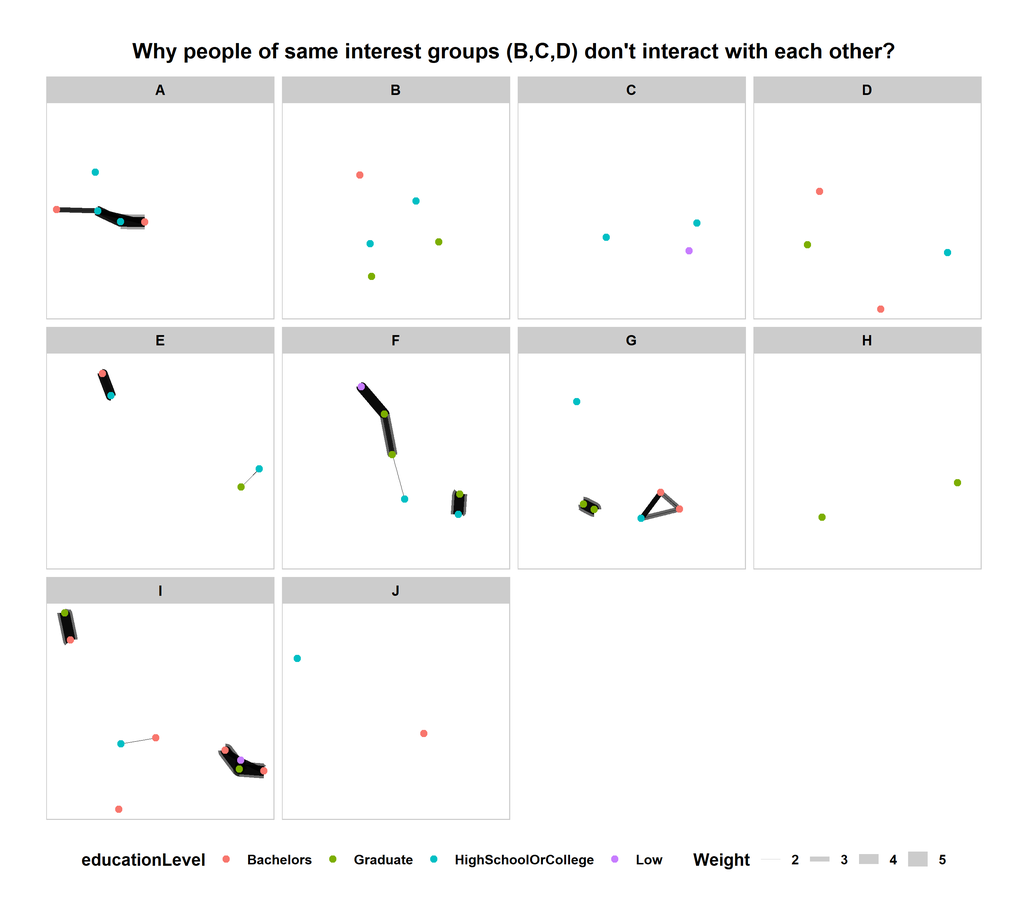

```r
set_graph_style()
g <- ggraph(social_graph,
            layout = "nicely") +
  geom_edge_link(aes(width=Weight),
                 alpha=0.2) +
  scale_edge_width(range = c(0.1, 5)) +
  geom_node_point(aes(colour = educationLevel),
                  size = 2)
g + facet_nodes(~interestGroup)+
  th_foreground(foreground = "grey80",
                border = TRUE) +
  labs(title="Why people of same interest groups (B,C,D) don't interact with each other?") +
  theme(plot.title = element_text(size=15, hjust = 0.5),
  legend.position = 'bottom',
  text = element_text(size=12,face="bold"))
```

### Observation

- It is observed that participants of interest groups B, C and D don’t interact much may be in this timeline despite July 2022 having maximum interactions overall.
- There may be a chance of happening any events in this month for the interest groups A,F,G & I and hence people of those interest groups are highly active.
- It is also observed that Interest Group I comprises of participants of different educational background.

### Revealing patterns of the least interactive month

```r
data_edges_aggregated <- data %>%
  filter(timestamp >= "2022-03-01" & timestamp <= "2022-03-31") %>%
  group_by(participantIdFrom , participantIdTo, Weekday) %>%
    dplyr::summarise(Weight = n()) %>%
  filter(participantIdFrom!=participantIdTo) %>%
  filter(Weight > 1) %>%
  ungroup()
saveRDS(data_edges_aggregated,'data/march2022_social_data.rds')
```

```r
data_edges <- readRDS("data/march2022_social_data.rds")
data_nodes <- read_csv("data/participants.csv")
data_nodes$ageGroup <- cut(data_nodes$age, breaks = c(17,35,60),labels = c('Young Adults','Old Adults'),include.lowest=TRUE)
```

### Reviewing the data

```r
glimpse(data_edges)
```

```
Rows: 49,284
Columns: 4
$ participantIdFrom <dbl> 0, 0, 0, 0, 0, 0, 0, 0, 0, 0, 0, 0, 0, 0, ~
$ participantIdTo   <dbl> 226, 226, 226, 226, 226, 226, 226, 644, 64~
$ Weekday           <chr> "Friday", "Monday", "Saturday", "Sunday", ~
$ Weight            <int> 2, 3, 2, 3, 2, 2, 2, 2, 2, 2, 3, 2, 2, 2, ~
```

```r
jov0.9 <- data_nodes %>%
  filter(joviality > 0.95)

jovEdge <- data_edges %>%
  filter(participantIdFrom %in% jov0.9$participantId & participantIdTo %in% jov0.9$participantId)

jovNode <-jov0.9 %>%
  filter(participantId %in% jovEdge$participantIdFrom & participantId %in% jovEdge$participantIdTo)
```

### Building data model

The below code chunk is to build an tidygraph’s network graph data.frame using `*tbl_graph()*` of tinygraph package.

```r
social_graph <- graph_from_data_frame(jovEdge, vertices = jovNode) %>%
  as_tbl_graph() %>%
  activate(edges) %>%
  arrange(desc(Weight))
social_graph
```

```
# A tbl_graph: 32 nodes and 416 edges
#
# A directed multigraph with 5 components
#
# Edge Data: 416 x 4 (active)
   from    to Weekday   Weight
  <int> <int> <chr>      <int>
1     4     5 Wednesday      5
2     5     4 Wednesday      5
3     6     8 Wednesday      5
4     8     6 Wednesday      5
5    11    16 Wednesday      5
6    12    15 Wednesday      5
# ... with 410 more rows
#
# Node Data: 32 x 8
  name  householdSize haveKids   age educationLevel interestGroup
  <chr>         <dbl> <lgl>    <dbl> <chr>          <chr>
1 104               2 FALSE       47 HighSchoolOrC~ F
2 113               2 FALSE       51 Graduate       G
3 165               2 FALSE       30 Graduate       G
# ... with 29 more rows, and 2 more variables: joviality <dbl>,
#   ageGroup <chr>
```

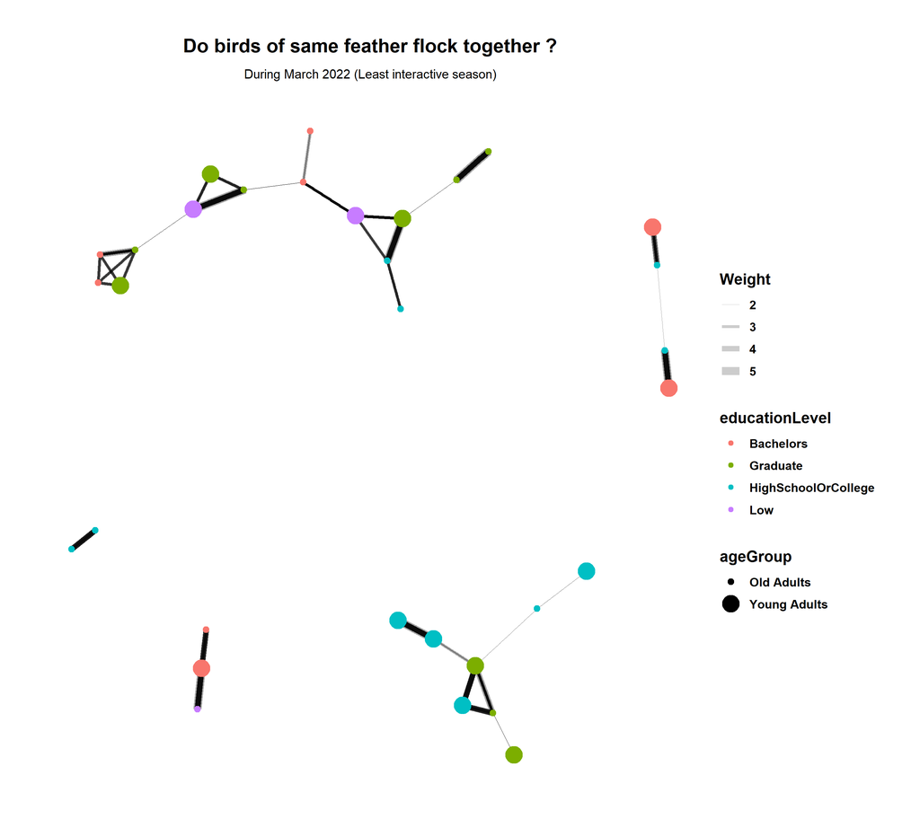

```r
g <- ggraph(social_graph,
            layout = "nicely") +
  geom_edge_link(aes(width=Weight),
                 alpha=0.2) +
  scale_edge_width(range = c(0.1, 3)) +
  geom_node_point(aes(colour = educationLevel,
                      size = ageGroup))
 g + theme_graph() +
  labs(fill = "Education Level",title="Do birds of same feather flock together ?",
       subtitle = "During March 2022 (Least interactive season)") +
  theme(plot.title = element_text(size=15, hjust = 0.5),
        plot.subtitle  = element_text(size = 10, hjust = 0.5),
        text = element_text(size=12,face="bold"))
```